# Budowanie modeli

Andrii Morozov

31 01 2021

# **NIEZBEDNE FUNKCJE**

```r
dfAS <- read.csv("WSE-ASSECOPOL.csv",sep = ",")
dfAS <- dfAS[nrow(dfAS):1,]
dfCD <- read.csv("WSE-CDPROJEKT.csv",sep = ",")
dfCD <- dfCD[nrow(dfCD):1,]
dfCY <- read.csv("WSE-CYFRPLSAT.csv",sep = ",")
dfCY <- dfCY[nrow(dfCY):1,]

stopaPR <- function(.df,.df1,.df2){
  VolatilityAS <- NULL
  VolatilityCD <- NULL
  VolatilityCY <- NULL
  for(i in 1:(nrow(.df)-1)){
    VolatilityAS[i] <- ((.df$Close[i+1]-.df$Close[i])/(.df$Close[i]))
    VolatilityCD[i] <- ((.df1$Close[i+1]-.df1$Close[i])/(.df1$Close[i]))
    VolatilityCY[i] <- ((.df2$Close[i+1]-.df2$Close[i])/(.df2$Close[i]))
  }
  #Volatility[nrow(.df)] <- NA
  final <- cbind(VolatilityAS,VolatilityCD,VolatilityCY)
  return(final)
}

EWMA <- function(.df){
  .varAS <- NULL
  .varCD <- NULL
  .varCY <- NULL
  .covAS.CD <- NULL
  .covAS.CY <- NULL
  .covCD.CY <- NULL
  lambda <- 0.94
  .varAS[1] <- var(.df$VolatilityAS[1:250])
  .varCD[1] <- var(.df$VolatilityCD[1:250])
  .varCY[1] <- var(.df$VolatilityCY[1:250])
  .covAS.CD[1] <- cov(.df$VolatilityAS[1:250],.df$VolatilityCD[1:250])
  .covAS.CY[1] <- cov(.df$VolatilityAS[1:250],.df$VolatilityCY[1:250])
  .covCD.CY[1] <- cov(.df$VolatilityCD[1:250],.df$VolatilityCY[1:250])
  for(i in 1:nrow(.df)){
    .varAS[i+1] <- .varAS[i]*lambda + ((1-lambda)*.df$VolatilityAS[i]^2)
    .varCD[i+1] <- .varCD[i]*lambda + ((1-lambda)*.df$VolatilityCD[i]^2)
    .varCY[i+1] <- .varCY[i]*lambda + ((1-lambda)*.df$VolatilityCY[i]^2)
    .covAS.CD[i+1] <- .covAS.CD[i]*lambda + ((1-lambda)*.df$VolatilityAS[i]*.df$VolatilityCD[i])
    .covAS.CY[i+1] <- .covAS.CY[i]*lambda + ((1-lambda)*.df$VolatilityAS[i]*.df$VolatilityCY[i])
    .covCD.CY[i+1] <- .covCD.CY[i]*lambda + ((1-lambda)*.df$VolatilityCD[i]*.df$VolatilityCY[i])
  }
  final <- cbind(.varAS,.varCD,.varCY,.covAS.CD,.covAS.CY,.covCD.CY)
  final <- as.data.frame(final)
  return(final)
}

mVaR <- function(.df){
  VaR99 <- NULL
  ES99 <- NULL
  VaR95 <- NULL
  ES95 <- NULL
  .corAS.CD <- NULL
  .corAS.CY <- NULL
  .corCD.CY <- NULL
  .row1 <- c(0.33,0.33,0.33)
  for(i in 2:nrow(.df)){
    .row2 <- c(.df$.varAS[i],.df$.covAS.CD[i],.df$.covAS.CY[i])
    .row3 <- c(.df$.covAS.CD[i],.df$.varCD[i],.df$.covCD.CY[i])
    .row4 <- c(.df$.covAS.CY[i],.df$.covCD.CY[i],.df$.varCY[i])
    macierz <- rbind(.row2,.row3,.row4)
    macierz1 <- .row1*macierz
    temp <- c(sum(macierz1[,1]),sum(macierz1[,2]),sum(macierz1[,3]))
    war.portfela <- sum(.row1*temp)
    SD.portfela <- sqrt(war.portfela)
    VaR99[i-1] <- 2.33*SD.portfela*100
    VaR95[i-1] <- 1.64*SD.portfela*100
    ES99[i-1] <- (SD.portfela*(exp(-(2.33^2)/2))/(sqrt(2*pi)*0.01))*100
    ES95[i-1] <- (SD.portfela*(exp(-(1.64^2)/2))/(sqrt(2*pi)*0.05))*100
    .SD <- c(sqrt(macierz[1,1]),sqrt(macierz[2,2]),sqrt(macierz[3,3]))
    .corAS.CD[i-1] <- macierz[1,2]/(.SD[1]*.SD[2])
    .corAS.CY[i-1] <- macierz[1,3]/(.SD[1]*.SD[3])
    .corCD.CY[i-1] <- macierz[2,3]/(.SD[2]*.SD[3])
  }
  final <- cbind(VaR99,ES99,VaR95,ES95,.corAS.CD,.corAS.CY,.corCD.CY)
  final <- as.data.frame(final)
  return(final)
}
```

# **WSTEP**

**Celem projektu** jest stworzyc model metoda EWMA, poprzez wyliczenia **VCOV** dla Var oraz ES.

**Hipoteza badawcza**: Wyniki symulacji VaR oraz ES **NIE** roznia sie istotnie.

**Opis danych**

```
## 'data.frame':    494 obs. of  9 variables:
##  $ Date           : chr  "2019-01-02" "2019-01-03" "2019-01-04" "2019-01-07" ...
##  $ Open           : num  46.2 46 46.4 46.8 47.5 ...
##  $ High           : num  46.8 46.5 47 47.9 48.2 ...
##  $ Low            : num  45.6 45.9 46.1 46.8 47.1 ...
##  $ Close          : num  46.5 46.5 46.8 47.6 47.6 ...
##  $ X.Change       : num  0.78 -0.04 0.65 1.8 0 1.93 -1.15 3.17 -2.91 0.96 ...
##  $ Volume         : num  92217 78056 29116 36402 34995 ...
##  $ X..of.Trades   : num  552 588 324 351 352 ...
##  $ Turnover..1000.: num  4270 3604 1360 1733 1668 ...
```

```
##           Date  Open  High   Low Close X.Change Volume X..of.Trades
## 494 2019-01-02 46.20 46.76 45.60 46.48     0.78  92217          552
## 493 2019-01-03 46.00 46.46 45.92 46.46    -0.04  78056          588
## 492 2019-01-04 46.40 46.98 46.06 46.76     0.65  29116          324
## 491 2019-01-07 46.76 47.94 46.76 47.60     1.80  36402          351
## 490 2019-01-08 47.48 48.20 47.14 47.60     0.00  34995          352
## 489 2019-01-09 47.90 49.64 47.90 48.52     1.93 193661         1047
##     Turnover..1000.
## 494         4270.05
## 493         3604.12
## 492         1359.63
## 491         1732.53
## 490         1668.46
## 489         9456.11
```

```
## 'data.frame':    494 obs. of  9 variables:
##  $ Date           : chr  "2019-01-02" "2019-01-03" "2019-01-04" "2019-01-07" ...
##  $ Open           : num  145 151 148 152 154 ...
##  $ High           : num  151 151 151 155 157 ...
##  $ Low            : num  142 147 148 152 152 ...
##  $ Close          : num  151 148 151 154 154 ...
##  $ X.Change       : num  3.71 -1.99 1.82 1.99 -0.07 7.42 3.64 -3.45 -3.39 1.76 ...
##  $ Volume         : num  197015 223586 163950 187987 278310 ...
##  $ X..of.Trades   : num  2941 2404 2164 2180 3084 ...
##  $ Turnover..1000.: num  29074 33262 24563 28778 42914 ...
```

```
##           Date  Open  High   Low Close X.Change Volume X..of.Trades
## 494 2019-01-02 145.4 151.3 142.1 151.0     3.71 197015         2941
## 493 2019-01-03 150.8 150.8 147.0 148.0    -1.99 223586         2404
## 492 2019-01-04 148.0 150.8 148.0 150.7     1.82 163950         2164
## 491 2019-01-07 152.0 154.6 151.5 153.7     1.99 187987         2180
## 490 2019-01-08 154.5 156.7 152.0 153.6    -0.07 278310         3084
## 489 2019-01-09 154.1 165.0 154.0 165.0     7.42 477150         5251
##     Turnover..1000.
## 494        29073.96
## 493        33262.31
## 492        24563.04
## 491        28777.64
## 490        42913.59
## 489        76972.53
```

```
## 'data.frame':    494 obs. of  9 variables:
##  $ Date           : chr  "2019-01-02" "2019-01-03" "2019-01-04" "2019-01-07" ...
##  $ Open           : num  22.4 22.5 22.5 23 22.4 ...
##  $ High           : num  22.6 22.7 23.1 23 22.6 ...
##  $ Low            : num  22.2 22.2 22.5 22.1 22.1 ...
##  $ Close          : num  22.5 22.4 22.6 22.4 22.4 ...
##  $ X.Change       : num  -0.18 -0.62 1.16 -1.24 0.18 2.23 0.7 -0.43 -0.17 1.4 ...
##  $ Volume         : num  127578 256731 308646 537561 830744 ...
##  $ X..of.Trades   : num  744 913 1318 1415 1712 ...
##  $ Turnover..1000.: num  2855 5741 7042 12032 18527 ...
```

```
##           Date  Open  High   Low Close X.Change Volume X..of.Trades
## 494 2019-01-02 22.42 22.62 22.22 22.52    -0.18 127578          744
## 493 2019-01-03 22.52 22.68 22.18 22.38    -0.62 256731          913
## 492 2019-01-04 22.52 23.10 22.48 22.64     1.16 308646         1318
## 491 2019-01-07 23.00 23.00 22.10 22.36    -1.24 537561         1415
## 490 2019-01-08 22.40 22.62 22.06 22.40     0.18 830744         1712
## 489 2019-01-09 22.46 23.08 22.34 22.90     2.23 873039         1475
##     Turnover..1000.
## 494         2855.24
## 493         5740.57
## 492         7042.09
## 491        12032.43
## 490        18526.83
## 489        19847.82
```

Dane zostaly pobrane ze strony **https://www.quandl.com/data/WARSAWSE-Warsaw-Stock-Exchange**.  
Zostaly wybrane dane z okresu **2019-01-02** do **2020-12-30**.  
W projekcie do obliczen stóp zwrotu byla wykorzystana kolumna **Close** (wartosc na koniec dnia).  
Byly wykorzystany proste stopy zwrotu.  
Zostaly wybrany spolki: **CDProjekt**,**ASSECOPOL** oraz **CYFRPLSAT**.  
#**VaR 99% oraz 95%**

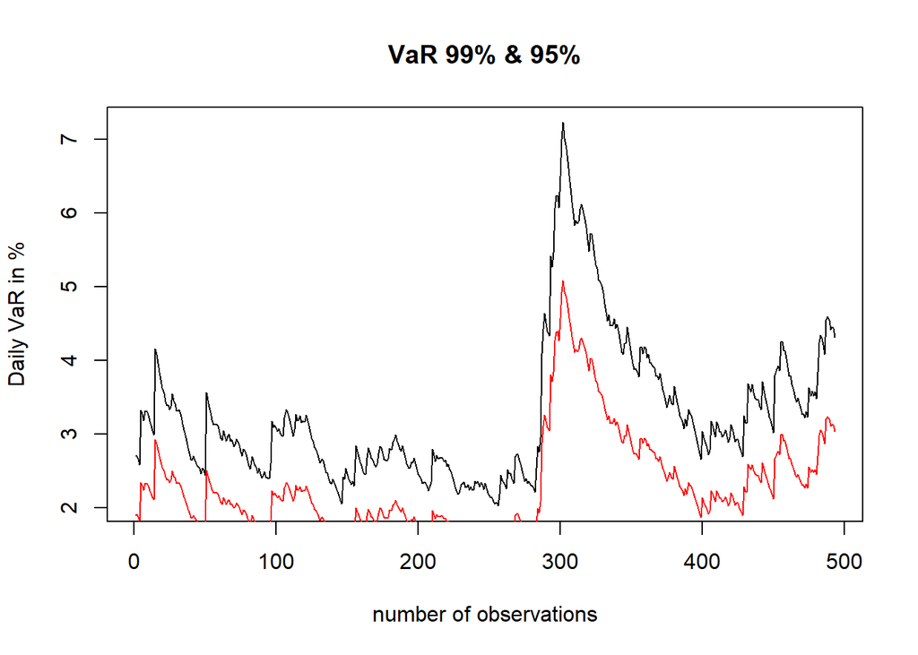

Na wykresie wyzej widzimy VaR 95% oraz **VaR 99%**. VaR 95% znajduje sie ponizej VaRu 99%, co jest zgodne z zalozeniami. Widzimy podobienstwo zachowywania VaRow.  
#**ES 99% oraz 95%**

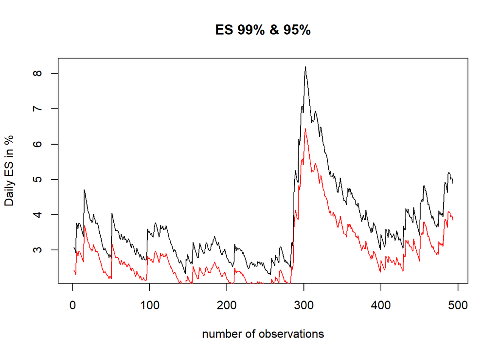

Na wykresie wyzej widzimy ES 95% oraz **ES 99%**. Tak samo jak i w przypadku dla VaR, ES zachowuje sie zgodnie z zalozeniami oraz wykresy dla 95% i 99% sa do siebie podobne. Sa rowniez podobienstwa z wykresami dla VaR 99% oraz 95% odpowiednio.  
#**Wykresy korelacji**

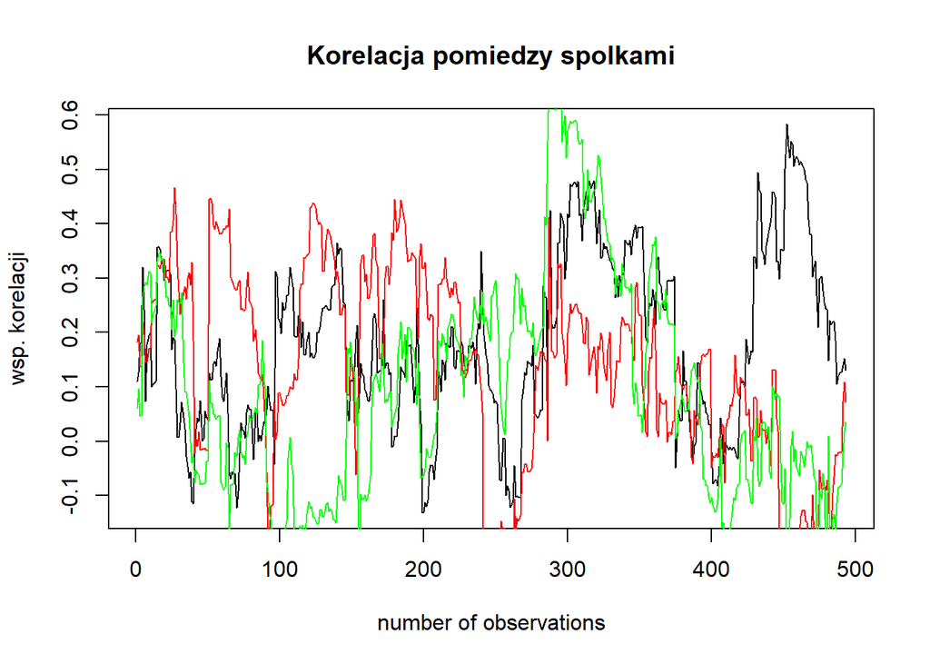

Na wykresie wyzej widzimy **Korelacje pomiedzy ASSECOPOL oraz CDPROJEKT**, ASSECOPOL oraz CYFRPLSAT, CDPROJEKT oraz CYFRPLSAT. Widzimy, ze korelacja pomiedzy spolkami zachowuje sie bardzo dynamicznie dla 1-dniowego VaRu, w przypadku spolek CDPROJECT/CYFRPLSAT wsp. korelacji z czasem zmienia sie od **-0.1** do **0.6**.  
#**PODSUMOWANIE**  
Z w.w. wykresow widac, ze wystepuja pewne podobienstwa dla VaR oraz ES. **Hipoteza badawcza** zostaje przyjeta, wyniki **NIE** roznia sie istotnie. W przypadku korelacji widzimy mocne skoki pomiedzy wartosciami, dla kazdego przypadku sa rozbieznosci od ujemno-slabej korelacji do mocno dodatniej.  
**DZIEKUJE ZA UWAGE**